# Chapter 3

### Excercise 9c

```r
lm.fit2 = lm(mpg~cylinders+displacement+horsepower+weight+acceleration+year+origin)
summary(lm.fit2)
```

```
##
## Call:
## lm(formula = mpg ~ cylinders + displacement + horsepower + weight +
##     acceleration + year + origin)
##
## Residuals:
##     Min      1Q  Median      3Q     Max
## -9.5903 -2.1565 -0.1169  1.8690 13.0604
##
## Coefficients:
##                Estimate Std. Error t value Pr(>|t|)
## (Intercept)  -17.218435   4.644294  -3.707  0.00024 ***
## cylinders     -0.493376   0.323282  -1.526  0.12780
## displacement   0.019896   0.007515   2.647  0.00844 **
## horsepower    -0.016951   0.013787  -1.230  0.21963
## weight        -0.006474   0.000652  -9.929  < 2e-16 ***
## acceleration   0.080576   0.098845   0.815  0.41548
## year           0.750773   0.050973  14.729  < 2e-16 ***
## origin         1.426141   0.278136   5.127 4.67e-07 ***
## ---
## Signif. codes:  0 '***' 0.001 '**' 0.01 '*' 0.05 '.' 0.1 ' ' 1
##
## Residual standard error: 3.328 on 384 degrees of freedom
## Multiple R-squared:  0.8215, Adjusted R-squared:  0.8182
## F-statistic: 252.4 on 7 and 384 DF,  p-value: < 2.2e-16
```

Comment:

1. Yes, there is.
2. Predictors including displacement, weigth, year and origin have a statistically significant relationship to the response.
3. The coeff for year indicates that for an additional year of car’s age, its mpg will on average increase by 0.75.

### Excercise 9d

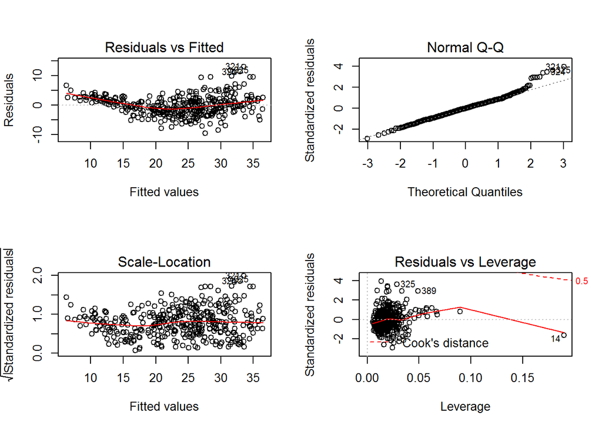

```r
par(mfrow = c(2,2))
plot(lm.fit2)
```

Comment:

### Excercise 9e

```r
par(mfrow = c(1,1))
lm.fit3 = lm(mpg~.-name + cylinders:horsepower, data = Auto)
summary(lm.fit3)
```

```
##
## Call:
## lm(formula = mpg ~ . - name + cylinders:horsepower, data = Auto)
##
## Residuals:
##     Min      1Q  Median      3Q     Max
## -9.2399 -1.6871 -0.0511  1.2858 11.9380
##
## Coefficients:
##                        Estimate Std. Error t value Pr(>|t|)
## (Intercept)          11.7025260  4.9115648   2.383 0.017676 *
## cylinders            -4.3060695  0.4580950  -9.400  < 2e-16 ***
## displacement         -0.0013925  0.0069110  -0.201 0.840426
## horsepower           -0.3156601  0.0306339 -10.304  < 2e-16 ***
## weight               -0.0038948  0.0006231  -6.250 1.09e-09 ***
## acceleration         -0.1703028  0.0901427  -1.889 0.059612 .
## year                  0.7393193  0.0448736  16.476  < 2e-16 ***
## origin                0.9031644  0.2496880   3.617 0.000338 ***
## cylinders:horsepower  0.0402008  0.0037856  10.619  < 2e-16 ***
## ---
## Signif. codes:  0 '***' 0.001 '**' 0.01 '*' 0.05 '.' 0.1 ' ' 1
##
## Residual standard error: 2.929 on 383 degrees of freedom
## Multiple R-squared:  0.8621, Adjusted R-squared:  0.8592
## F-statistic: 299.3 on 8 and 383 DF,  p-value: < 2.2e-16
```

### Excercise 9f

```r
lm.fit4 = lm(mpg~.-name + cylinders:horsepower + I(year^0.5) + log(weight), data = Auto)
summary(lm.fit4)
```

```
##
## Call:
## lm(formula = mpg ~ . - name + cylinders:horsepower + I(year^0.5) +
##     log(weight), data = Auto)
##
## Residuals:
##     Min      1Q  Median      3Q     Max
## -8.9174 -1.4148  0.0091  1.2757 11.8719
##
## Coefficients:
##                        Estimate Std. Error t value Pr(>|t|)
## (Intercept)           1.756e+03  2.876e+02   6.105 2.53e-09 ***
## cylinders            -2.764e+00  5.847e-01  -4.727 3.22e-06 ***
## displacement         -2.076e-03  6.724e-03  -0.309  0.75771
## horsepower           -2.235e-01  4.111e-02  -5.435 9.80e-08 ***
## weight                2.837e-03  1.965e-03   1.443  0.14971
## acceleration         -1.296e-01  8.821e-02  -1.469  0.14260
## year                  2.204e+01  3.697e+00   5.963 5.67e-09 ***
## origin                7.805e-01  2.440e-01   3.199  0.00150 **
## I(year^0.5)          -3.711e+02  6.445e+01  -5.757 1.76e-08 ***
## log(weight)          -1.995e+01  6.175e+00  -3.230  0.00134 **
## cylinders:horsepower  2.575e-02  5.417e-03   4.753 2.84e-06 ***
## ---
## Signif. codes:  0 '***' 0.001 '**' 0.01 '*' 0.05 '.' 0.1 ' ' 1
##
## Residual standard error: 2.793 on 381 degrees of freedom
## Multiple R-squared:  0.8752, Adjusted R-squared:  0.8719
## F-statistic: 267.2 on 10 and 381 DF,  p-value: < 2.2e-16
```

```r
anova(lm.fit3, lm.fit4)
```

```
## Analysis of Variance Table
##
## Model 1: mpg ~ (cylinders + displacement + horsepower + weight + acceleration +
##     year + origin + name) - name + cylinders:horsepower
## Model 2: mpg ~ (cylinders + displacement + horsepower + weight + acceleration +
##     year + origin + name) - name + cylinders:horsepower + I(year^0.5) +
##     log(weight)
##   Res.Df    RSS Df Sum of Sq      F    Pr(>F)
## 1    383 3285.0
## 2    381 2972.4  2    312.61 20.035 5.329e-09 ***
## ---
## Signif. codes:  0 '***' 0.001 '**' 0.01 '*' 0.05 '.' 0.1 ' ' 1
```

```r
# clean up
rm(list = setdiff(ls(), lsf.str()))
detach(Auto)
```

Comment:

Results of ANOVA indicate that the multiple linear model with non-linear transformation of the predictors are superior.

### Excercise 10a

```r
attach(Carseats)
lm.fit1 = lm(Sales ~ Price + Urban + US)
summary(lm.fit1)
```

```
##
## Call:
## lm(formula = Sales ~ Price + Urban + US)
##
## Residuals:
##     Min      1Q  Median      3Q     Max
## -6.9206 -1.6220 -0.0564  1.5786  7.0581
##
## Coefficients:
##              Estimate Std. Error t value Pr(>|t|)
## (Intercept) 13.043469   0.651012  20.036  < 2e-16 ***
## Price       -0.054459   0.005242 -10.389  < 2e-16 ***
## UrbanYes    -0.021916   0.271650  -0.081    0.936
## USYes        1.200573   0.259042   4.635 4.86e-06 ***
## ---
## Signif. codes:  0 '***' 0.001 '**' 0.01 '*' 0.05 '.' 0.1 ' ' 1
##
## Residual standard error: 2.472 on 396 degrees of freedom
## Multiple R-squared:  0.2393, Adjusted R-squared:  0.2335
## F-statistic: 41.52 on 3 and 396 DF,  p-value: < 2.2e-16
```

### Excercise 10b

Interpretation of each coefficient in the mode: 1. Price: for addtional one dollar increase in price, the sales will on average decrease by 54 units. 2. UrbanYes: if the store is in an urban location, the sales will on average decrease by 22 units. 3. USYes: if the store is in US, the sales will on average increase by 1,200 units.

### Excercise 10c

${y_i} = {\beta _0} + {\beta _1}{x_i} + {\beta _2}{x_i} + {\varepsilon _i} = \left\{ {\begin{array}{*{20}{c}} {{\beta _0} + {\varepsilon _i},{\rm{~if~i-th~store~is~in~rural~area,~and~is~not~in~US}}}\\ {\begin{array}{*{20}{c}} {{\beta _0} + {\beta _1} + {\varepsilon _i},{\rm{~if~i-th~store~is~in~urban~area}}}\\ {\begin{array}{*{20}{c}} {{\beta _0} + {\beta _2} + {\varepsilon _i},{\rm{~if~i-th~store~is~in~US}}}\\ \end{array}} \end{array}} \end{array}} \right.$

### Excercise 10e

```r
lm.fit2 = lm(Sales ~ Price + US)
summary(lm.fit2)
```

```
##
## Call:
## lm(formula = Sales ~ Price + US)
##
## Residuals:
##     Min      1Q  Median      3Q     Max
## -6.9269 -1.6286 -0.0574  1.5766  7.0515
##
## Coefficients:
##             Estimate Std. Error t value Pr(>|t|)
## (Intercept) 13.03079    0.63098  20.652  < 2e-16 ***
## Price       -0.05448    0.00523 -10.416  < 2e-16 ***
## USYes        1.19964    0.25846   4.641 4.71e-06 ***
## ---
## Signif. codes:  0 '***' 0.001 '**' 0.01 '*' 0.05 '.' 0.1 ' ' 1
##
## Residual standard error: 2.469 on 397 degrees of freedom
## Multiple R-squared:  0.2393, Adjusted R-squared:  0.2354
## F-statistic: 62.43 on 2 and 397 DF,  p-value: < 2.2e-16
```

### Excercise 10f

```r
anova(lm.fit1, lm.fit2)
```

```
## Analysis of Variance Table
##
## Model 1: Sales ~ Price + Urban + US
## Model 2: Sales ~ Price + US
##   Res.Df    RSS Df Sum of Sq      F Pr(>F)
## 1    396 2420.8
## 2    397 2420.9 -1  -0.03979 0.0065 0.9357
```

Results of ANOVA failed to reject null hypothesis, meaning the two models fit the data equally well.

### Excercise 10g

```r
confint(lm.fit2, level = 0.95)
```

```
##                   2.5 %      97.5 %
## (Intercept) 11.79032020 14.27126531
## Price       -0.06475984 -0.04419543
## USYes        0.69151957  1.70776632
```

### Excercise 10h

Plotting *residual vs fitted value* and *studentized residual vs fitted value*:

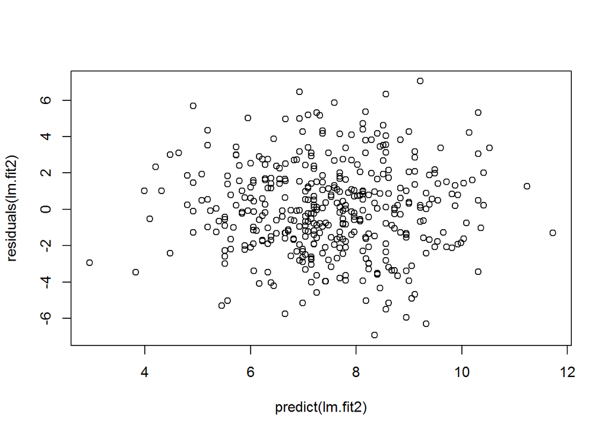

```r
plot(predict(lm.fit2), residuals(lm.fit2))
```

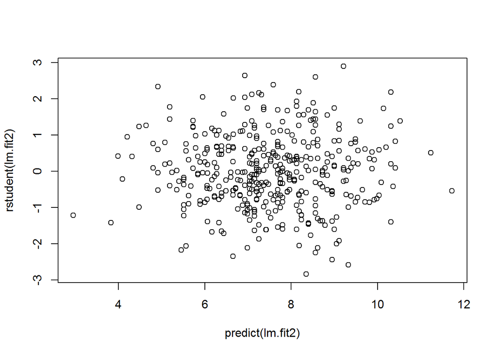

```r
plot(predict(lm.fit2), rstudent(lm.fit2))
```

Above plots show no evidence of outliers, since the absolute value of studentized residuals of all oberservations are less than 3.

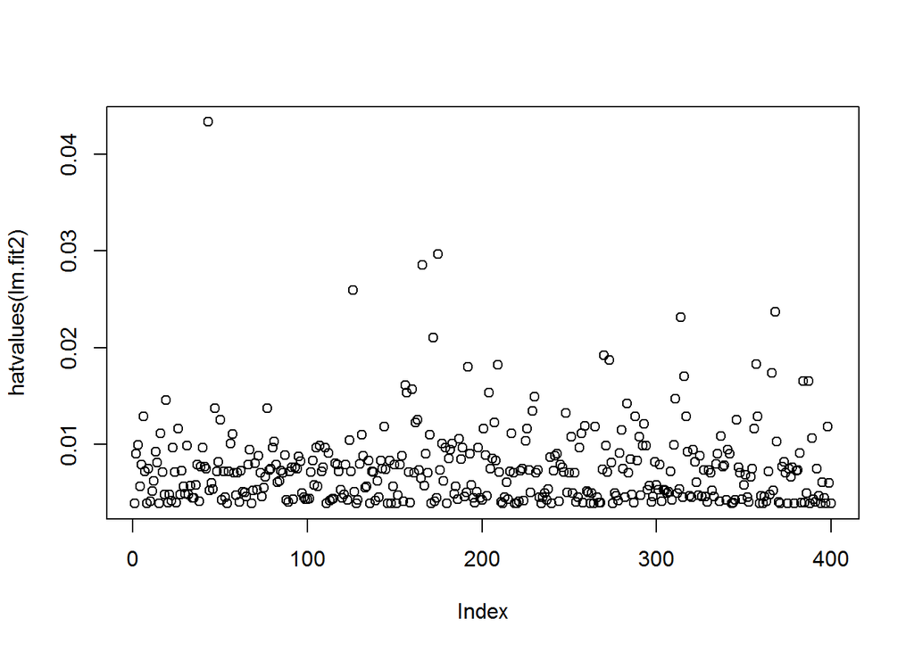

```r
plot(hatvalues(lm.fit2))
```

```r
which.max(hatvalues(lm.fit2))
```

```
## 43
## 43
```

Above plot shows that there exists one high leverage point (*NO.* 43).

```r
# clean up
rm(list = setdiff(ls(), lsf.str()))
par(mfrow = c(1,1))
```

### Excercise 11a

```r
set.seed(1)
x = rnorm(100)
y = 2*x + rnorm(100)
```

```r
lm.fit1 = lm(y~x+0) # without intercept term
summary(lm.fit1)
```

```
##
## Call:
## lm(formula = y ~ x + 0)
##
## Residuals:
##     Min      1Q  Median      3Q     Max
## -1.9154 -0.6472 -0.1771  0.5056  2.3109
##
## Coefficients:
##   Estimate Std. Error t value Pr(>|t|)
## x   1.9939     0.1065   18.73   <2e-16 ***
## ---
## Signif. codes:  0 '***' 0.001 '**' 0.01 '*' 0.05 '.' 0.1 ' ' 1
##
## Residual standard error: 0.9586 on 99 degrees of freedom
## Multiple R-squared:  0.7798, Adjusted R-squared:  0.7776
## F-statistic: 350.7 on 1 and 99 DF,  p-value: < 2.2e-16
```

Comment:

1. The p-value indicates that the probability of obversing $\beta_x = 1.9939$ or more extrem cases provided that $H_0: \beta_x = 0$ is almost zero.
2. ${\rm R}^2 = 0.7798$ shows that $77.98\%$ of the Total sum of Squares (TSS) have been explained by the simple linear regression model.

### Excercise 11b

```r
lm.fit2 = lm(x~y+0) # without intercept term
summary(lm.fit2)
```

```
##
## Call:
## lm(formula = x ~ y + 0)
##
## Residuals:
##     Min      1Q  Median      3Q     Max
## -0.8699 -0.2368  0.1030  0.2858  0.8938
##
## Coefficients:
##   Estimate Std. Error t value Pr(>|t|)
## y  0.39111    0.02089   18.73   <2e-16 ***
## ---
## Signif. codes:  0 '***' 0.001 '**' 0.01 '*' 0.05 '.' 0.1 ' ' 1
##
## Residual standard error: 0.4246 on 99 degrees of freedom
## Multiple R-squared:  0.7798, Adjusted R-squared:  0.7776
## F-statistic: 350.7 on 1 and 99 DF,  p-value: < 2.2e-16
```

1. The p-value indicates that the probability of obversing $\beta_y = 0.391$ or more extrem cases provided that $H_0: \beta_y = 0$ is almost zero.
2. ${\rm R}^2 = 0.7798$ shows that $77.98\%$ of the Total sum of Squares (TSS) have been explained by the simple linear regression model.

### Excercise 11c

The results obtained in (a) have the same ${\rm R}^2$, adjusted ${\rm R}^2$, t value and F-statistic with results in (b).

### Excercise 11d

$\begin{array}{cc} t = \beta / SE(\beta) & \beta = \frac {\sum{x_i y_i}} {\sum{x_i^2}} & SE(\beta) = \sqrt{\frac {\sum{(y_i - x_i \beta)^2}} {(n-1) \sum{x_i^2}}} \end{array} \\ \begin{array}{cl} t & = & {\frac {\sum{x_i y_i}} {\sum{x_i^2}}} {\sqrt{\frac {(n-1) \sum{x_i^2}} {\sum{(y_i - x_i \beta)^2}}}} \\ & = & \frac {\sqrt{n-1} \sum{x_i y_i}} {\sqrt{\sum{x_i^2} \sum{(y_i - x_i \beta)^2}}} \\ & = & \frac {\sqrt{n-1} \sum{x_i y_i}} {\sqrt{\sum{x_i^2} \sum{(y_i^2 - 2 \beta x_i y_i + x_i^2 \beta^2)}}} \\ & = & \frac {\sqrt{n-1} \sum{x_i y_i}} {\sqrt{\sum{x_i^2} \sum{y_i^2} - \sum{x_i^2} \beta (2 \sum{x_i y_i} - \beta \sum{x_i^2})}} \\ & = & \frac {\sqrt{n-1} \sum{x_i y_i}} {\sqrt{\sum{x_i^2} \sum{y_i^2} - \sum{x_i y_i} (2 \sum{x_i y_i} - \sum{x_i y_i})}} \\ & = & \frac {\sqrt{n-1} \sum{x_i y_i}} {\sqrt{\sum{x_i^2} \sum{y_i^2} - (\sum{x_i y_i})^2 }} \end{array}$

```r
sqrt(length(x) - 1) * sum(x*y) / sqrt(sum(x^2)*sum(y^2) - sum(x*y)^2)
```

```
## [1] 18.72593
```

The t-statistic has been verified to be the same with results of the two simple linear regressions.

### Excercise 11e

Given the result of (d), notwithstanding we change $x$ with $y$, t-statistic remains same for the regression of $x$ onto $y$, comparing to the regression of $y$ onto $x$.

### Excercise 11f

```r
lm.fit_y_onto_x = lm(y~x)
summary(lm.fit_y_onto_x)
```

```
##
## Call:
## lm(formula = y ~ x)
##
## Residuals:
##     Min      1Q  Median      3Q     Max
## -1.8768 -0.6138 -0.1395  0.5394  2.3462
##
## Coefficients:
##             Estimate Std. Error t value Pr(>|t|)
## (Intercept) -0.03769    0.09699  -0.389    0.698
## x            1.99894    0.10773  18.556   <2e-16 ***
## ---
## Signif. codes:  0 '***' 0.001 '**' 0.01 '*' 0.05 '.' 0.1 ' ' 1
##
## Residual standard error: 0.9628 on 98 degrees of freedom
## Multiple R-squared:  0.7784, Adjusted R-squared:  0.7762
## F-statistic: 344.3 on 1 and 98 DF,  p-value: < 2.2e-16
```

```r
lm.fit_x_onto_y = lm(x~y)
summary(lm.fit_x_onto_y)
```

```
##
## Call:
## lm(formula = x ~ y)
##
## Residuals:
##      Min       1Q   Median       3Q      Max
## -0.90848 -0.28101  0.06274  0.24570  0.85736
##
## Coefficients:
##             Estimate Std. Error t value Pr(>|t|)
## (Intercept)  0.03880    0.04266    0.91    0.365
## y            0.38942    0.02099   18.56   <2e-16 ***
## ---
## Signif. codes:  0 '***' 0.001 '**' 0.01 '*' 0.05 '.' 0.1 ' ' 1
##
## Residual standard error: 0.4249 on 98 degrees of freedom
## Multiple R-squared:  0.7784, Adjusted R-squared:  0.7762
## F-statistic: 344.3 on 1 and 98 DF,  p-value: < 2.2e-16
```

```r
# clean up
rm(list = setdiff(ls(), lsf.str()))
```

The t-statistic for above two models are same (18.56).

### Excercise 12a

$\frac{{\sum {{x_i}{y_i}} }}{{\sum {x_i^2} }} = \frac{{\sum {{y_i}{x_i}} }}{{\sum {y_i^2} }}$ Therefore, when $\sum {x_i^2} = \sum {y_i^2}$, the coefficient estimate for the regression of $X$ onto $Y$ is the same as the one for regression of $Y$ on $X$.

### Excercise 12b

```r
set.seed(1)
x = rnorm(100)
y = 2*x
sum(x^2)
```

```
## [1] 81.05509
```

```r
sum(y^2)
```

```
## [1] 324.2204
```

```r
lm.fit1 = lm(y ~ x + 0)
lm.fit2 = lm(x ~ y + 0)
summary(lm.fit1)
```

```
##
## Call:
## lm(formula = y ~ x + 0)
##
## Residuals:
##        Min         1Q     Median         3Q        Max
## -3.776e-16 -3.378e-17  2.680e-18  6.113e-17  5.105e-16
##
## Coefficients:
##    Estimate Std. Error   t value Pr(>|t|)
## x 2.000e+00  1.296e-17 1.543e+17   <2e-16 ***
## ---
## Signif. codes:  0 '***' 0.001 '**' 0.01 '*' 0.05 '.' 0.1 ' ' 1
##
## Residual standard error: 1.167e-16 on 99 degrees of freedom
## Multiple R-squared:      1,  Adjusted R-squared:      1
## F-statistic: 2.382e+34 on 1 and 99 DF,  p-value: < 2.2e-16
```

```r
summary(lm.fit2)
```

```
##
## Call:
## lm(formula = x ~ y + 0)
##
## Residuals:
##        Min         1Q     Median         3Q        Max
## -1.888e-16 -1.689e-17  1.339e-18  3.057e-17  2.552e-16
##
## Coefficients:
##   Estimate Std. Error   t value Pr(>|t|)
## y 5.00e-01   3.24e-18 1.543e+17   <2e-16 ***
## ---
## Signif. codes:  0 '***' 0.001 '**' 0.01 '*' 0.05 '.' 0.1 ' ' 1
##
## Residual standard error: 5.833e-17 on 99 degrees of freedom
## Multiple R-squared:      1,  Adjusted R-squared:      1
## F-statistic: 2.382e+34 on 1 and 99 DF,  p-value: < 2.2e-16
```

The regression coefficient estimates are different for above two models.

### Excercise 12c

```r
set.seed(1)
x = rnorm(100)
y = sample(x, replace = FALSE, 100) # a random permutation
sum(x^2)
```

```
## [1] 81.05509
```

```r
sum(y^2)
```

```
## [1] 81.05509
```

```r
lm.fit1 = lm(y ~ x + 0)
lm.fit2 = lm(x ~ y + 0)
summary(lm.fit1)
```

```
##
## Call:
## lm(formula = y ~ x + 0)
##
## Residuals:
##     Min      1Q  Median      3Q     Max
## -2.2315 -0.5124  0.1027  0.6877  2.3926
##
## Coefficients:
##   Estimate Std. Error t value Pr(>|t|)
## x  0.02148    0.10048   0.214    0.831
##
## Residual standard error: 0.9046 on 99 degrees of freedom
## Multiple R-squared:  0.0004614,  Adjusted R-squared:  -0.009635
## F-statistic: 0.0457 on 1 and 99 DF,  p-value: 0.8312
```

```r
summary(lm.fit2)
```

```
##
## Call:
## lm(formula = x ~ y + 0)
##
## Residuals:
##     Min      1Q  Median      3Q     Max
## -2.2400 -0.5154  0.1213  0.6788  2.3959
##
## Coefficients:
##   Estimate Std. Error t value Pr(>|t|)
## y  0.02148    0.10048   0.214    0.831
##
## Residual standard error: 0.9046 on 99 degrees of freedom
## Multiple R-squared:  0.0004614,  Adjusted R-squared:  -0.009635
## F-statistic: 0.0457 on 1 and 99 DF,  p-value: 0.8312
```

The regression coefficient estimates are same for above two models.

```r
# clean up
rm(list = setdiff(ls(), lsf.str()))
```

### Excercise 13a

```r
set.seed(1)
x = rnorm(100)
```

### Excercise 13b

```r
eps = rnorm(100, mean = 0, sd = 0.25)
```

### Excercise 13c

```r
y = -1 + 0.5 * x + eps
length(y)
```

```
## [1] 100
```

### Excercise 13d

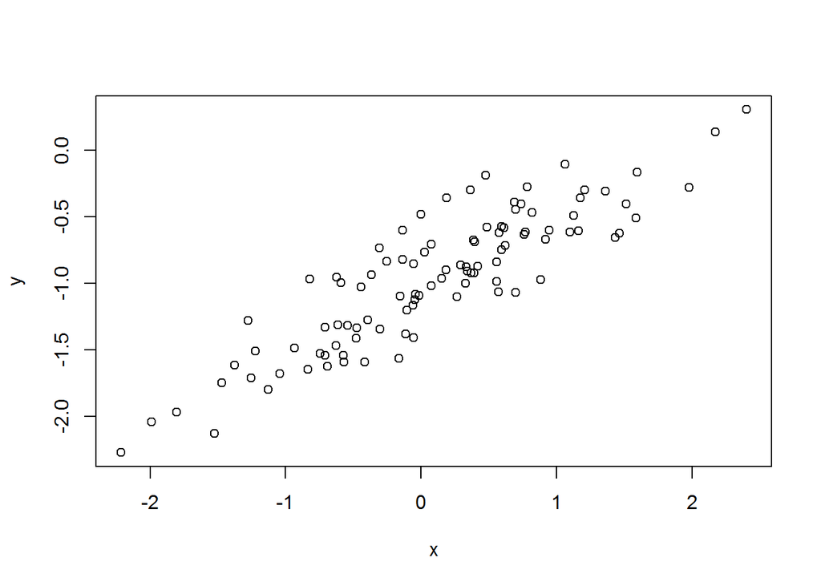

```r
plot(x, y)
```

Comment:

$x$ and $y$ has a positive correlation.

### Excercise 13e

```r
lm.fit = lm(y~x)
summary(lm.fit)
```

```
##
## Call:
## lm(formula = y ~ x)
##
## Residuals:
##      Min       1Q   Median       3Q      Max
## -0.46921 -0.15344 -0.03487  0.13485  0.58654
##
## Coefficients:
##             Estimate Std. Error t value Pr(>|t|)
## (Intercept) -1.00942    0.02425  -41.63   <2e-16 ***
## x            0.49973    0.02693   18.56   <2e-16 ***
## ---
## Signif. codes:  0 '***' 0.001 '**' 0.01 '*' 0.05 '.' 0.1 ' ' 1
##
## Residual standard error: 0.2407 on 98 degrees of freedom
## Multiple R-squared:  0.7784, Adjusted R-squared:  0.7762
## F-statistic: 344.3 on 1 and 98 DF,  p-value: < 2.2e-16
```

Comment:

${\hat \beta _0}$ and ${\hat \beta _1}$ are *almost* same with $\beta_0$ and $\beta_1$.

### Excercise 13f

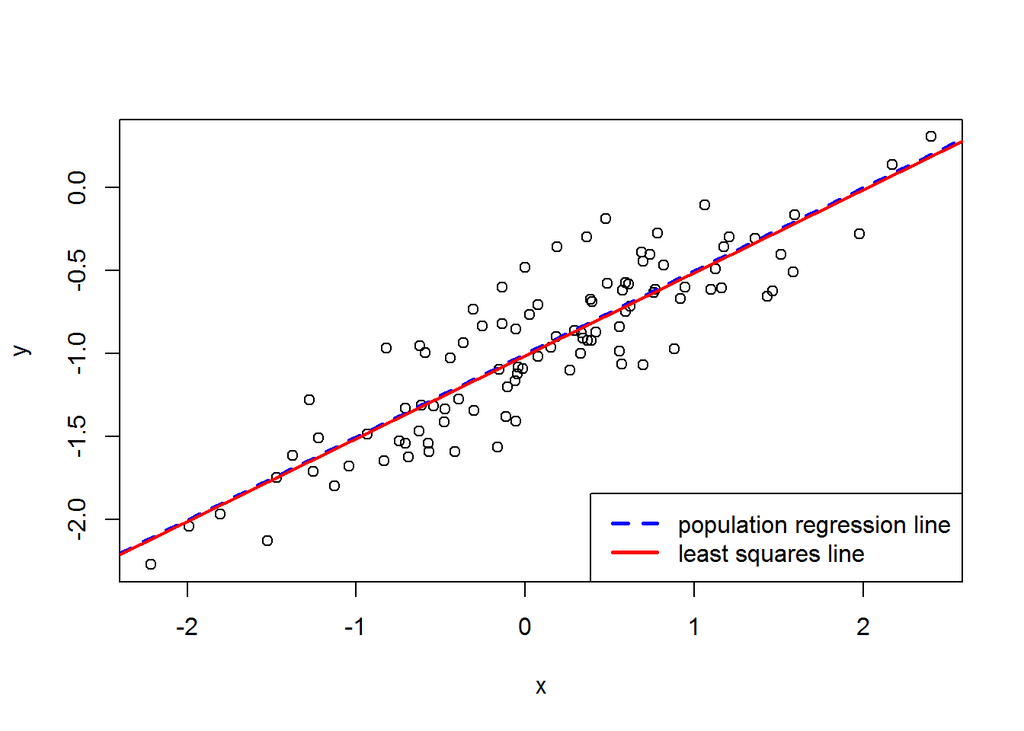

```r
plot(x, y)
abline(-1, 0.5, lwd = 2, col = "blue", lty = "dashed")
abline(lm.fit, lwd = 2, col = "red")
legend("bottomright", c("population regression line", "least squares line"),
       lty=c(2,1), # gives the legend appropriate symbols (lines)
       lwd=c(2.5,2.5), col=c("blue","red")) # gives the legend lines the correct color and width
```

### Excercise 13g

```r
lm.fit2 = lm(y ~ x + I(x^2))
summary(lm.fit2)
```

```
##
## Call:
## lm(formula = y ~ x + I(x^2))
##
## Residuals:
##     Min      1Q  Median      3Q     Max
## -0.4913 -0.1563 -0.0322  0.1451  0.5675
##
## Coefficients:
##             Estimate Std. Error t value Pr(>|t|)
## (Intercept) -0.98582    0.02941 -33.516   <2e-16 ***
## x            0.50429    0.02700  18.680   <2e-16 ***
## I(x^2)      -0.02973    0.02119  -1.403    0.164
## ---
## Signif. codes:  0 '***' 0.001 '**' 0.01 '*' 0.05 '.' 0.1 ' ' 1
##
## Residual standard error: 0.2395 on 97 degrees of freedom
## Multiple R-squared:  0.7828, Adjusted R-squared:  0.7784
## F-statistic: 174.8 on 2 and 97 DF,  p-value: < 2.2e-16
```

### Excercise 13h

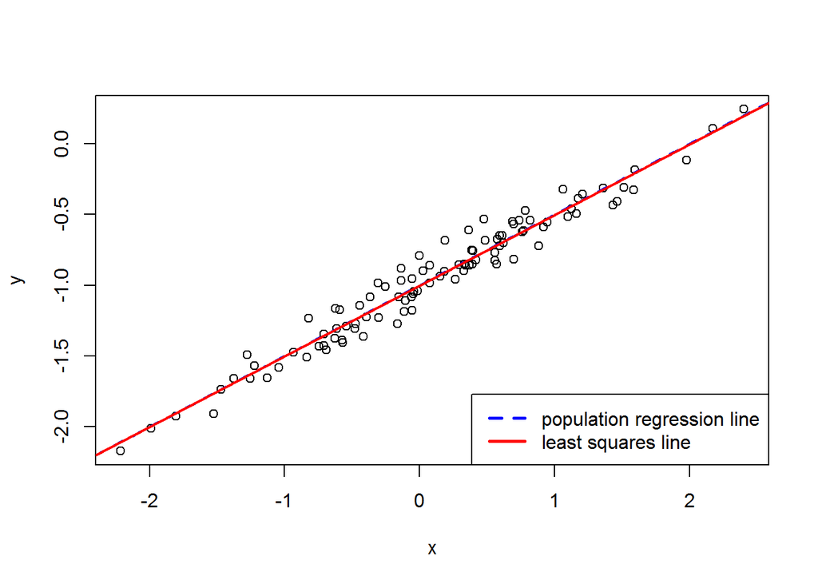

```r
set.seed(1)
x = rnorm(100)
eps = rnorm(100, mean = 0, sd = 0.1)
y = -1 + 0.5 * x + eps
lm.fit3 = lm(y~x)
plot(x, y)
abline(-1, 0.5, lwd = 2, col = "blue", lty = "dashed")
abline(lm.fit3, lwd = 2, col = "red")
legend("bottomright", c("population regression line", "least squares line"),
       lty=c(2,1), # gives the legend appropriate symbols (lines)
       lwd=c(2.5,2.5), col=c("blue","red")) # gives the legend lines the correct color and width
```

```r
summary(lm.fit3)
```

```
##
## Call:
## lm(formula = y ~ x)
##
## Residuals:
##      Min       1Q   Median       3Q      Max
## -0.18768 -0.06138 -0.01395  0.05394  0.23462
##
## Coefficients:
##              Estimate Std. Error t value Pr(>|t|)
## (Intercept) -1.003769   0.009699  -103.5   <2e-16 ***
## x            0.499894   0.010773    46.4   <2e-16 ***
## ---
## Signif. codes:  0 '***' 0.001 '**' 0.01 '*' 0.05 '.' 0.1 ' ' 1
##
## Residual standard error: 0.09628 on 98 degrees of freedom
## Multiple R-squared:  0.9565, Adjusted R-squared:  0.956
## F-statistic:  2153 on 1 and 98 DF,  p-value: < 2.2e-16
```

Comparing to the regression results of original dataset, ${\rm R}^2$ has been increased from 0.7784 to 0.9565, indicating that the model fits current dataset better.

### Excercise 13i

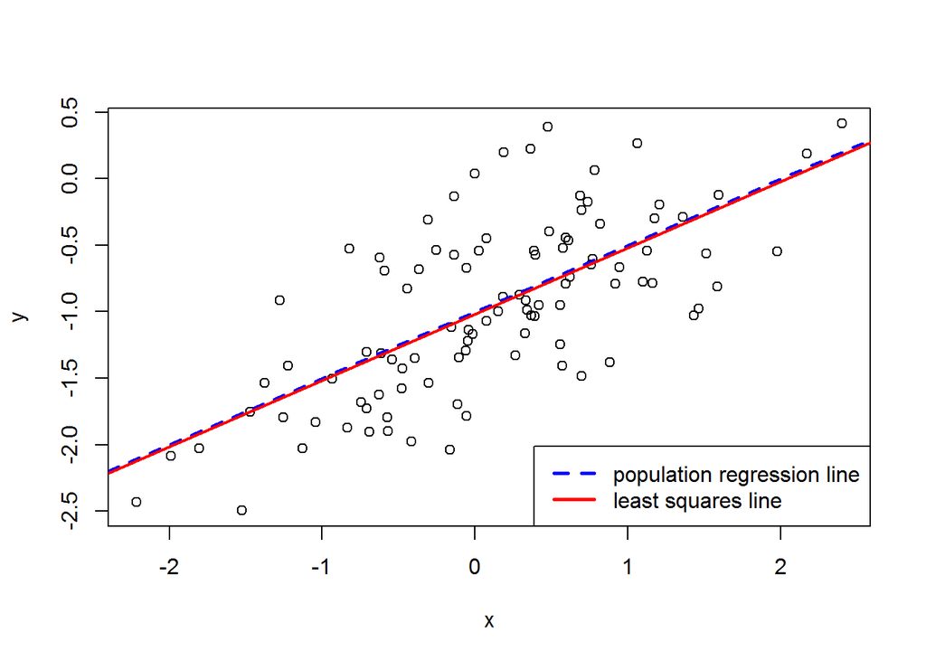

```r
set.seed(1)
x = rnorm(100)
eps = rnorm(100, mean = 0, sd = 0.5)
y = -1 + 0.5 * x + eps
lm.fit4 = lm(y~x)
plot(x, y)
abline(-1, 0.5, lwd = 2, col = "blue", lty = "dashed")
abline(lm.fit4, lwd = 2, col = "red")
legend("bottomright", c("population regression line", "least squares line"),
       lty=c(2,1), # gives the legend appropriate symbols (lines)
       lwd=c(2.5,2.5), col=c("blue","red")) # gives the legend lines the correct color and width
```

```r
summary(lm.fit4)
```

```
##
## Call:
## lm(formula = y ~ x)
##
## Residuals:
##      Min       1Q   Median       3Q      Max
## -0.93842 -0.30688 -0.06975  0.26970  1.17309
##
## Coefficients:
##             Estimate Std. Error t value Pr(>|t|)
## (Intercept) -1.01885    0.04849 -21.010  < 2e-16 ***
## x            0.49947    0.05386   9.273 4.58e-15 ***
## ---
## Signif. codes:  0 '***' 0.001 '**' 0.01 '*' 0.05 '.' 0.1 ' ' 1
##
## Residual standard error: 0.4814 on 98 degrees of freedom
## Multiple R-squared:  0.4674, Adjusted R-squared:  0.4619
## F-statistic: 85.99 on 1 and 98 DF,  p-value: 4.583e-15
```

Comparing to the regression results of original dataset, ${\rm R}^2$ has been decreased from 0.7784 to 0.4674, indicating that the model fits original dataset better.

### Excercise 13j

```r
confint(lm.fit)  # original dataset
```

```
##                  2.5 %     97.5 %
## (Intercept) -1.0575402 -0.9613061
## x            0.4462897  0.5531801
```

```r
confint(lm.fit3) # less noisy dataset
```

```
##                  2.5 %     97.5 %
## (Intercept) -1.0230161 -0.9845224
## x            0.4785159  0.5212720
```

```r
confint(lm.fit4) # noiser dataset
```

```
##                  2.5 %     97.5 %
## (Intercept) -1.1150804 -0.9226122
## x            0.3925794  0.6063602
```

```r
# clean up
rm(list = setdiff(ls(), lsf.str()))
```

Comment:

Rank in ascending order based on the width of confidence interval for coefficients of both intercept and $x$:

less noisy dataset < original dataset < noisier dataset

### Excercise 14a

```r
set.seed(1)
x1 = runif(100)
x2 = 0.5* x1 + rnorm(100)/10
y = 2 + 2*x1 + 0.3*x2 + rnorm(100)
```

$\begin{array}{l} y = {\beta _0} + {\beta _1}{x_1} + {\beta _2}{x_2} + \varepsilon \\ {\beta _0} = 2\\ {\beta _1} = 2\\ {\beta _2} = 0.3 \end{array}$

### Excercise 14b

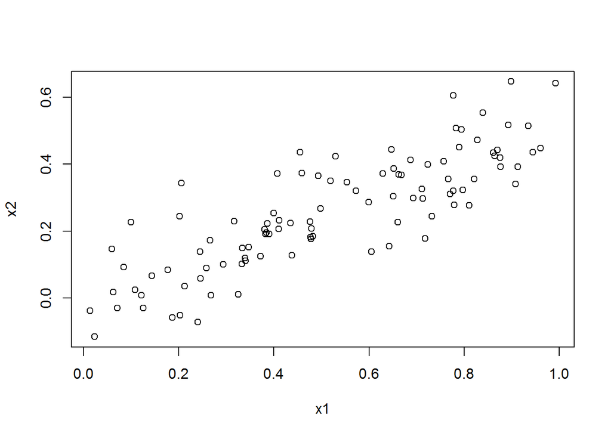

```r
plot(x1, x2)
```

Above plot shows $x_1$ has a positive correlation with $x_1$.

### Excercise 14c

```r
lm.fit = lm(y ~ x1 + x2)
summary(lm.fit)
```

```
##
## Call:
## lm(formula = y ~ x1 + x2)
##
## Residuals:
##     Min      1Q  Median      3Q     Max
## -2.8311 -0.7273 -0.0537  0.6338  2.3359
##
## Coefficients:
##             Estimate Std. Error t value Pr(>|t|)
## (Intercept)   2.1305     0.2319   9.188 7.61e-15 ***
## x1            1.4396     0.7212   1.996   0.0487 *
## x2            1.0097     1.1337   0.891   0.3754
## ---
## Signif. codes:  0 '***' 0.001 '**' 0.01 '*' 0.05 '.' 0.1 ' ' 1
##
## Residual standard error: 1.056 on 97 degrees of freedom
## Multiple R-squared:  0.2088, Adjusted R-squared:  0.1925
## F-statistic:  12.8 on 2 and 97 DF,  p-value: 1.164e-05
```

$\hat \beta_0 = 2.13$, $\hat \beta_1 = 1.44$ and $\hat \beta_2 = 1.01$

P-value for $H_0: \hat \beta_2 = 0$ is 0.3754, which is much greater than cutoff value, therefore there is not enough evidence to reject $H_0: \hat \beta_2 = 0$.

### Excercise 14d

```r
lm.fit2 = lm(y ~ x1)
summary(lm.fit2)
```

```
##
## Call:
## lm(formula = y ~ x1)
##
## Residuals:
##      Min       1Q   Median       3Q      Max
## -2.89495 -0.66874 -0.07785  0.59221  2.45560
##
## Coefficients:
##             Estimate Std. Error t value Pr(>|t|)
## (Intercept)   2.1124     0.2307   9.155 8.27e-15 ***
## x1            1.9759     0.3963   4.986 2.66e-06 ***
## ---
## Signif. codes:  0 '***' 0.001 '**' 0.01 '*' 0.05 '.' 0.1 ' ' 1
##
## Residual standard error: 1.055 on 98 degrees of freedom
## Multiple R-squared:  0.2024, Adjusted R-squared:  0.1942
## F-statistic: 24.86 on 1 and 98 DF,  p-value: 2.661e-06
```

P-value for $H_0: \hat \beta_1 = 0$ is nearly 0, therefore we can reject the null hypothesis.

### Excercise 14e

```r
lm.fit3 = lm(y ~ x2)
summary(lm.fit3)
```

```
##
## Call:
## lm(formula = y ~ x2)
##
## Residuals:
##      Min       1Q   Median       3Q      Max
## -2.62687 -0.75156 -0.03598  0.72383  2.44890
##
## Coefficients:
##             Estimate Std. Error t value Pr(>|t|)
## (Intercept)   2.3899     0.1949   12.26  < 2e-16 ***
## x2            2.8996     0.6330    4.58 1.37e-05 ***
## ---
## Signif. codes:  0 '***' 0.001 '**' 0.01 '*' 0.05 '.' 0.1 ' ' 1
##
## Residual standard error: 1.072 on 98 degrees of freedom
## Multiple R-squared:  0.1763, Adjusted R-squared:  0.1679
## F-statistic: 20.98 on 1 and 98 DF,  p-value: 1.366e-05
```

P-value for $H_0: \hat \beta_2 = 0$ is nearly 0, therefore we can reject the null hypothesis.

### Excercise 14g

```r
summary(x1)
```

```
##    Min. 1st Qu.  Median    Mean 3rd Qu.    Max.
## 0.01339 0.32310 0.48780 0.51780 0.76720 0.99190
```

```r
summary(x2)
```

```
##    Min. 1st Qu.  Median    Mean 3rd Qu.    Max.
## -0.1160  0.1384  0.2486  0.2572  0.3763  0.6472
```

```r
x1 = c(x1, 0.1)
x2 = c(x2, 0.8)
y = c(y, 6)
```

```r
par(mfrow = c(2,2))
lm.fit4 = lm(y ~ x1 + x2)
summary(lm.fit4)
```

```
##
## Call:
## lm(formula = y ~ x1 + x2)
##
## Residuals:
##      Min       1Q   Median       3Q      Max
## -2.73348 -0.69318 -0.05263  0.66385  2.30619
##
## Coefficients:
##             Estimate Std. Error t value Pr(>|t|)
## (Intercept)   2.2267     0.2314   9.624 7.91e-16 ***
## x1            0.5394     0.5922   0.911  0.36458
## x2            2.5146     0.8977   2.801  0.00614 **
## ---
## Signif. codes:  0 '***' 0.001 '**' 0.01 '*' 0.05 '.' 0.1 ' ' 1
##
## Residual standard error: 1.075 on 98 degrees of freedom
## Multiple R-squared:  0.2188, Adjusted R-squared:  0.2029
## F-statistic: 13.72 on 2 and 98 DF,  p-value: 5.564e-06
```

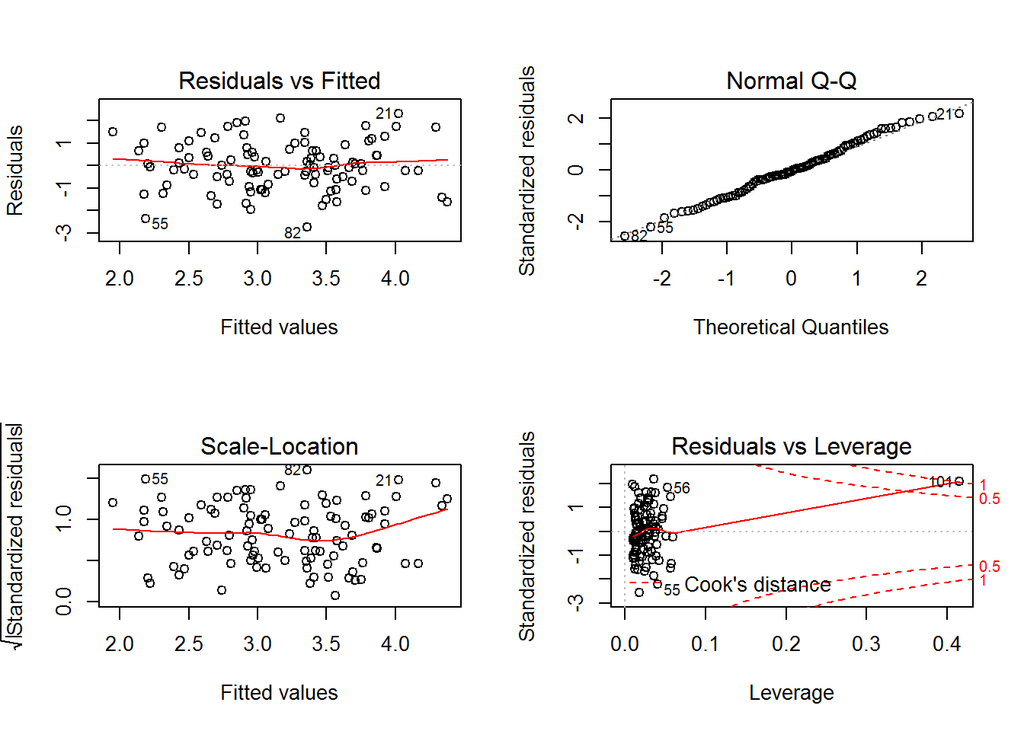

```r
plot(lm.fit4)
```

```r
lm.fit5 = lm(y ~ x1)
summary(lm.fit5)
```

```
##
## Call:
## lm(formula = y ~ x1)
##
## Residuals:
##     Min      1Q  Median      3Q     Max
## -2.8897 -0.6556 -0.0909  0.5682  3.5665
##
## Coefficients:
##             Estimate Std. Error t value Pr(>|t|)
## (Intercept)   2.2569     0.2390   9.445 1.78e-15 ***
## x1            1.7657     0.4124   4.282 4.29e-05 ***
## ---
## Signif. codes:  0 '***' 0.001 '**' 0.01 '*' 0.05 '.' 0.1 ' ' 1
##
## Residual standard error: 1.111 on 99 degrees of freedom
## Multiple R-squared:  0.1562, Adjusted R-squared:  0.1477
## F-statistic: 18.33 on 1 and 99 DF,  p-value: 4.295e-05
```

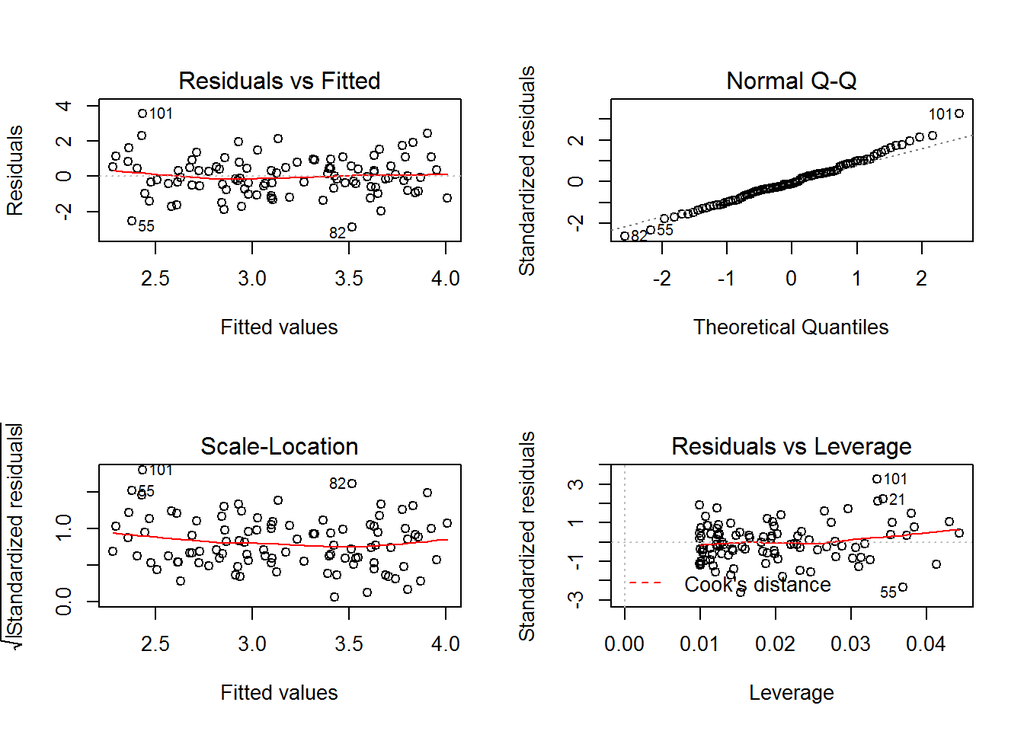

```r
plot(lm.fit5)
```

```r
lm.fit6 = lm(y ~ x2)
summary(lm.fit6)
```

```
##
## Call:
## lm(formula = y ~ x2)
##
## Residuals:
##      Min       1Q   Median       3Q      Max
## -2.64729 -0.71021 -0.06899  0.72699  2.38074
##
## Coefficients:
##             Estimate Std. Error t value Pr(>|t|)
## (Intercept)   2.3451     0.1912  12.264  < 2e-16 ***
## x2            3.1190     0.6040   5.164 1.25e-06 ***
## ---
## Signif. codes:  0 '***' 0.001 '**' 0.01 '*' 0.05 '.' 0.1 ' ' 1
##
## Residual standard error: 1.074 on 99 degrees of freedom
## Multiple R-squared:  0.2122, Adjusted R-squared:  0.2042
## F-statistic: 26.66 on 1 and 99 DF,  p-value: 1.253e-06
```

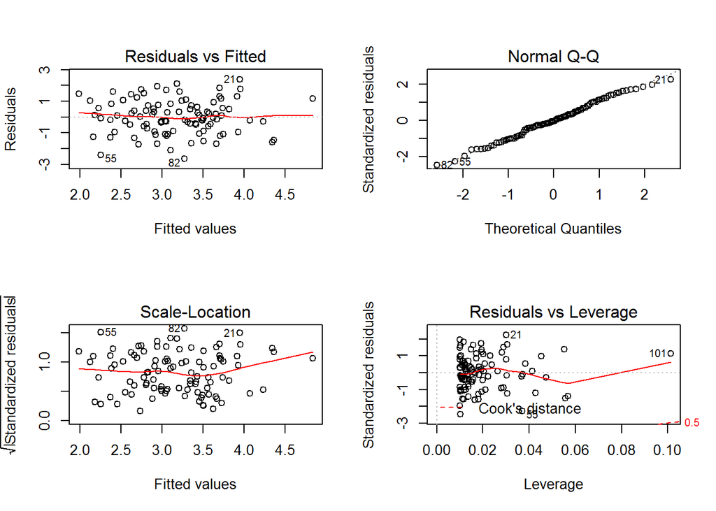

```r
plot(lm.fit6)
```

After adding new observation in $x_1$, the ${\rm R}^2$ has been decreased from 0.2024 to 0.1562, meaning the newly added observation is an outlier. Furthurmore, the second plots also shows that the newly added observation in $x_1$ is an outlier.

The third plot shows that the newly added observation in $x_2$ is a high leverage point.

```r
# clean up
rm(list = setdiff(ls(), lsf.str()))
par(mfrow = c(1,1))
```

### Excercise 15a

```r
library(MASS)
attach(Boston)
sim_beta_js = c()
for ( name in names(Boston)[-1] ) {
  predictor =  c(t(subset(Boston, select = name)))
  lm.fit = lm(crim ~ predictor)
  sim_beta_js <- c(sim_beta_js, coef(lm.fit)[2])
  print(paste("Running simple linear regression on:", name))
  print(summary(lm.fit))
}
```

```
## [1] "Running simple linear regression on: zn"
##
## Call:
## lm(formula = crim ~ predictor)
##
## Residuals:
##    Min     1Q Median     3Q    Max
## -4.429 -4.222 -2.620  1.250 84.523
##
## Coefficients:
##             Estimate Std. Error t value Pr(>|t|)
## (Intercept)  4.45369    0.41722  10.675  < 2e-16 ***
## predictor   -0.07393    0.01609  -4.594 5.51e-06 ***
## ---
## Signif. codes:  0 '***' 0.001 '**' 0.01 '*' 0.05 '.' 0.1 ' ' 1
##
## Residual standard error: 8.435 on 504 degrees of freedom
## Multiple R-squared:  0.04019,    Adjusted R-squared:  0.03828
## F-statistic:  21.1 on 1 and 504 DF,  p-value: 5.506e-06
##
## [1] "Running simple linear regression on: indus"
##
## Call:
## lm(formula = crim ~ predictor)
##
## Residuals:
##     Min      1Q  Median      3Q     Max
## -11.972  -2.698  -0.736   0.712  81.813
##
## Coefficients:
##             Estimate Std. Error t value Pr(>|t|)
## (Intercept) -2.06374    0.66723  -3.093  0.00209 **
## predictor    0.50978    0.05102   9.991  < 2e-16 ***
## ---
## Signif. codes:  0 '***' 0.001 '**' 0.01 '*' 0.05 '.' 0.1 ' ' 1
##
## Residual standard error: 7.866 on 504 degrees of freedom
## Multiple R-squared:  0.1653, Adjusted R-squared:  0.1637
## F-statistic: 99.82 on 1 and 504 DF,  p-value: < 2.2e-16
##
```

[output cut: 204 more lines]

```
##
## Residuals:
##    Min     1Q Median     3Q    Max
## -9.071 -4.022 -2.343  1.298 80.957
##
## Coefficients:
##             Estimate Std. Error t value Pr(>|t|)
## (Intercept) 11.79654    0.93419   12.63   <2e-16 ***
## predictor   -0.36316    0.03839   -9.46   <2e-16 ***
## ---
## Signif. codes:  0 '***' 0.001 '**' 0.01 '*' 0.05 '.' 0.1 ' ' 1
##
## Residual standard error: 7.934 on 504 degrees of freedom
## Multiple R-squared:  0.1508, Adjusted R-squared:  0.1491
## F-statistic: 89.49 on 1 and 504 DF,  p-value: < 2.2e-16
```

All predictors except **chas** are statistical significant.

### Excercise 15b

```r
lm.fit = lm(crim ~ ., data = Boston)
summary(lm.fit)
```

```
##
## Call:
## lm(formula = crim ~ ., data = Boston)
##
## Residuals:
##    Min     1Q Median     3Q    Max
## -9.924 -2.120 -0.353  1.019 75.051
##
## Coefficients:
##               Estimate Std. Error t value Pr(>|t|)
## (Intercept)  17.033228   7.234903   2.354 0.018949 *
## zn            0.044855   0.018734   2.394 0.017025 *
## indus        -0.063855   0.083407  -0.766 0.444294
## chas         -0.749134   1.180147  -0.635 0.525867
## nox         -10.313535   5.275536  -1.955 0.051152 .
## rm            0.430131   0.612830   0.702 0.483089
## age           0.001452   0.017925   0.081 0.935488
## dis          -0.987176   0.281817  -3.503 0.000502 ***
## rad           0.588209   0.088049   6.680 6.46e-11 ***
## tax          -0.003780   0.005156  -0.733 0.463793
## ptratio      -0.271081   0.186450  -1.454 0.146611
## black        -0.007538   0.003673  -2.052 0.040702 *
## lstat         0.126211   0.075725   1.667 0.096208 .
## medv         -0.198887   0.060516  -3.287 0.001087 **
## ---
## Signif. codes:  0 '***' 0.001 '**' 0.01 '*' 0.05 '.' 0.1 ' ' 1
##
## Residual standard error: 6.439 on 492 degrees of freedom
## Multiple R-squared:  0.454,  Adjusted R-squared:  0.4396
## F-statistic: 31.47 on 13 and 492 DF,  p-value: < 2.2e-16
```

### Excercise 15c

Results in (b) have much more predictors which are not statistically significant comparing to the results in (a).

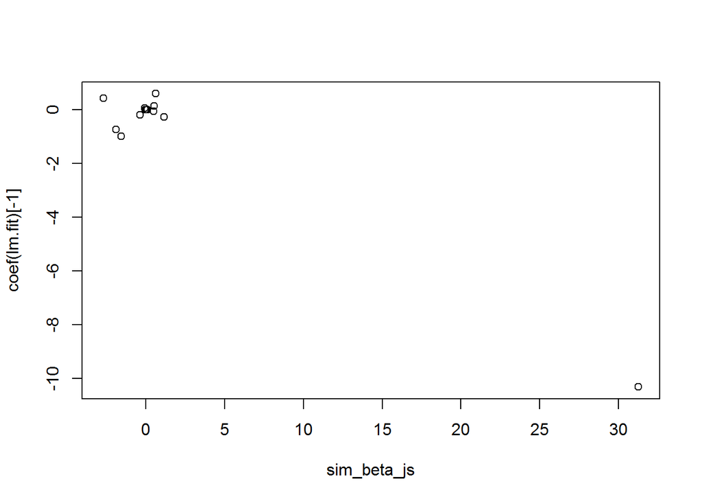

```r
plot(sim_beta_js, coef(lm.fit)[-1])
```

```r
names(Boston)[which.max(sim_beta_js)+1]
```

```
## [1] "nox"
```

```r
coef(lm.fit)[which.max(sim_beta_js)+1] # in multiple regression model
```

```
##       nox
## -10.31353
```

```r
max(sim_beta_js) # in univariate regression model
```

```
## [1] 31.24853
```

Predictor **nox** has univariate regression coefficient estimate of 31 and multiple regression coefficient estimate of -10.

### Excercise 15d

```r
for ( name in names(Boston)[-1] ) {
  predictor =  c(t(subset(Boston, select = name)))
  lm.fit = lm(crim ~ predictor + I(predictor^2) + I(predictor^3)) # adding non-linearity
  print(paste("Running simple linear regression on:", name))
  print(summary(lm.fit))
}
```

```
## [1] "Running simple linear regression on: zn"
##
## Call:
## lm(formula = crim ~ predictor + I(predictor^2) + I(predictor^3))
##
## Residuals:
##    Min     1Q Median     3Q    Max
## -4.821 -4.614 -1.294  0.473 84.130
##
## Coefficients:
##                  Estimate Std. Error t value Pr(>|t|)
## (Intercept)     4.846e+00  4.330e-01  11.192  < 2e-16 ***
## predictor      -3.322e-01  1.098e-01  -3.025  0.00261 **
## I(predictor^2)  6.483e-03  3.861e-03   1.679  0.09375 .
## I(predictor^3) -3.776e-05  3.139e-05  -1.203  0.22954
## ---
## Signif. codes:  0 '***' 0.001 '**' 0.01 '*' 0.05 '.' 0.1 ' ' 1
##
## Residual standard error: 8.372 on 502 degrees of freedom
## Multiple R-squared:  0.05824,    Adjusted R-squared:  0.05261
## F-statistic: 10.35 on 3 and 502 DF,  p-value: 1.281e-06
##
## [1] "Running simple linear regression on: indus"
##
## Call:
## lm(formula = crim ~ predictor + I(predictor^2) + I(predictor^3))
##
## Residuals:
##    Min     1Q Median     3Q    Max
## -8.278 -2.514  0.054  0.764 79.713
##
## Coefficients:
##                  Estimate Std. Error t value Pr(>|t|)
## (Intercept)     3.6625683  1.5739833   2.327   0.0204 *
## predictor      -1.9652129  0.4819901  -4.077 5.30e-05 ***
## I(predictor^2)  0.2519373  0.0393221   6.407 3.42e-10 ***
## I(predictor^3) -0.0069760  0.0009567  -7.292 1.20e-12 ***
## ---
## Signif. codes:  0 '***' 0.001 '**' 0.01 '*' 0.05 '.' 0.1 ' ' 1
##
```

[output cut: 226 more lines]

```
##     Min      1Q  Median      3Q     Max
## -24.427  -1.976  -0.437   0.439  73.655
##
## Coefficients:
##                  Estimate Std. Error t value Pr(>|t|)
## (Intercept)    53.1655381  3.3563105  15.840  < 2e-16 ***
## predictor      -5.0948305  0.4338321 -11.744  < 2e-16 ***
## I(predictor^2)  0.1554965  0.0171904   9.046  < 2e-16 ***
## I(predictor^3) -0.0014901  0.0002038  -7.312 1.05e-12 ***
## ---
## Signif. codes:  0 '***' 0.001 '**' 0.01 '*' 0.05 '.' 0.1 ' ' 1
##
## Residual standard error: 6.569 on 502 degrees of freedom
## Multiple R-squared:  0.4202, Adjusted R-squared:  0.4167
## F-statistic: 121.3 on 3 and 502 DF,  p-value: < 2.2e-16
```

There are evidences of non-linear association between predictor and response for **indus**, **nox**, **dis**, **ptratio**, and **medv**.